# Project: TMDB Movies Data analysis

- Introduction
- Data Wrangling
- Exploratory Data Analysis
- Conclusions

## Introduction

In this project, the TMDB movie dataset is analyzed. The dataset contains records for movies since 1960 to 2015. Each record represents some characteristics for each movie. Our aim in this analysis is to understand the relationship between movie genre and its revenue and popularity. To achieve this goal we to try to answer some questions that we will mention later in this section but lets first have a brief description of each column in the dataset.

- id - This is infact the movie_id as in the first dataset.
- imdb_id - A unique identifier for each movie in imdb dataset.
- cast - The name of lead and supporting actors.
- budget - The budget in which the movie was made.
- genre - The genre of the movie, Action, Comedy ,Thriller etc.
- homepage - A link to the homepage of the movie.
- keywords - The keywords or tags related to the movie.
- original_title - The title of the movie before translation or adaptation.
- overview - A brief description of the movie.
- popularity - A numeric quantity specifying the movie popularity.
- production_companies - The production house of the movie.
- release_date - The date on which it was released.
- release_year - The year on which it was released.
- revenue - The worldwide revenue generated by the movie.
- runtime - The running time of the movie in minutes.
- tagline - Movie's tagline.
- vote_average - average ratings the movie recieved.
- vote_count - the count of votes recieved.
- budget_adj - The budget in which the movie was made adjusted for inflation.
- revenue_adj - The worldwide revenue generated by the movie adjusted for inflation.

This analysis will try to answer the following questions:

- Q1: Which genres have the highest revenues?
- Q2: How the top 5 genres' revenue changed over time?
- Q3: Which genres are most popular?
- Q4: How the top 5 popular genres changed over time?
- Q5: Who is the director whose movies got the highest revenues?

```python
import pandas as pd
import numpy as np
import matplotlib.pyplot as plt
import itertools

# Limiting floats output to 2 decimal points and adding the thousands
# operator that places a comma between all thousands
pd.set_option('display.float_format', lambda x: '{:,.2f}'.format(x))

%matplotlib inline
```

## Data Wrangling

### General Properties

```python
# Load the data
url = "https://github.com/moazmagdy/TMDB_Movie_Data_Analysis/raw/master/tmdb-movies.csv"
data = pd.read_csv(url)
#Check number of records and features in the dataset.
print('There are: {0} rows and {1} columns'.format(data.shape[0], data.shape[1]))
```

```
There are: 10866 rows and 21 columns
```

```python
#Data at first glance
data.head(3).transpose()
```

|  | 0 | 1 | 2 |
| --- | --- | --- | --- |
| id | 135397 | 76341 | 262500 |
| imdb_id | tt0369610 | tt1392190 | tt2908446 |
| popularity | 32.99 | 28.42 | 13.11 |
| budget | 150000000 | 150000000 | 110000000 |
| revenue | 1513528810 | 378436354 | 295238201 |
| original_title | Jurassic World | Mad Max: Fury Road | Insurgent |
| cast | Chris Pratt\|Bryce Dallas Howard\|Irrfan Khan\|Vi... | Tom Hardy\|Charlize Theron\|Hugh Keays-Byrne\|Nic... | Shailene Woodley\|Theo James\|Kate Winslet\|Ansel... |
| homepage | http://www.jurassicworld.com/ | http://www.madmaxmovie.com/ | http://www.thedivergentseries.movie/#insurgent |
| director | Colin Trevorrow | George Miller | Robert Schwentke |
| tagline | The park is open. | What a Lovely Day. | One Choice Can Destroy You |
| keywords | monster\|dna\|tyrannosaurus rex\|velociraptor\|island | future\|chase\|post-apocalyptic\|dystopia\|australia | based on novel\|revolution\|dystopia\|sequel\|dyst... |
| overview | Twenty-two years after the events of Jurassic ... | An apocalyptic story set in the furthest reach... | Beatrice Prior must confront her inner demons ... |
| runtime | 124 | 120 | 119 |
| genres | Action\|Adventure\|Science Fiction\|Thriller | Action\|Adventure\|Science Fiction\|Thriller | Adventure\|Science Fiction\|Thriller |
| production_companies | Universal Studios\|Amblin Entertainment\|Legenda... | Village Roadshow Pictures\|Kennedy Miller Produ... | Summit Entertainment\|Mandeville Films\|Red Wago... |
| release_date | 6/9/15 | 5/13/15 | 3/18/15 |
| vote_count | 5562 | 6185 | 2480 |
| vote_average | 6.50 | 7.10 | 6.30 |
| release_year | 2015 | 2015 | 2015 |
| budget_adj | 137,999,939.28 | 137,999,939.28 | 101,199,955.47 |
| revenue_adj | 1,392,445,892.52 | 348,161,292.49 | 271,619,025.41 |

Columns such as cast, keywords, genres, director and production_company have textual data separated by "|". It would be better to convert columns into list of strings rather than dealing with one long string.

#### Data types

Check the data type for each column in the dataset.

```python
#check data types
data.dtypes
```

```
id                        int64
imdb_id                  object
popularity              float64
budget                    int64
revenue                   int64
original_title           object
cast                     object
homepage                 object
director                 object
tagline                  object
keywords                 object
overview                 object
runtime                   int64
genres                   object
production_companies     object
release_date             object
vote_count                int64
vote_average            float64
release_year              int64
budget_adj              float64
revenue_adj             float64
dtype: object
```

We can notice that release_date is object data type rather than datetime. Also, release_year is of int type rather that datetime.

**Number of columns of each data type:**

```python
#Data types summary
data.dtypes.value_counts()
```

```
object     11
int64       6
float64     4
dtype: int64
```

**Exploring columns with object data type**

Let's calculate summary statistics for object data type columns such as the number of unique values, the most common value and it's frequency.

```python
data[data.dtypes[data.dtypes == 'object'].index].describe().transpose()
```

|  | count | unique | top | freq |
| --- | --- | --- | --- | --- |
| imdb_id | 10856 | 10855 | tt0411951 | 2 |
| original_title | 10866 | 10571 | Hamlet | 4 |
| cast | 10790 | 10719 | Louis C.K. | 6 |
| homepage | 2936 | 2896 | http://www.missionimpossible.com/ | 4 |
| director | 10822 | 5067 | Woody Allen | 45 |
| tagline | 8042 | 7997 | Based on a true story. | 5 |
| keywords | 9373 | 8804 | woman director | 134 |
| overview | 10862 | 10847 | No overview found. | 13 |
| genres | 10843 | 2039 | Comedy | 712 |
| production_companies | 9836 | 7445 | Paramount Pictures | 156 |
| release_date | 10866 | 5909 | 1/1/09 | 28 |

**Exploring columns with numeric data types**

Get summary statistics for columns having numeric data types.

```python
data[data.dtypes[data.dtypes != 'object'].index].describe().transpose()
```

|  | count | mean | std | min | 25% | 50% | 75% | max |
| --- | --- | --- | --- | --- | --- | --- | --- | --- |
| id | 10,866.00 | 66,064.18 | 92,130.14 | 5.00 | 10,596.25 | 20,669.00 | 75,610.00 | 417,859.00 |
| popularity | 10,866.00 | 0.65 | 1.00 | 0.00 | 0.21 | 0.38 | 0.71 | 32.99 |
| budget | 10,866.00 | 14,625,701.09 | 30,913,213.83 | 0.00 | 0.00 | 0.00 | 15,000,000.00 | 425,000,000.00 |
| revenue | 10,866.00 | 39,823,319.79 | 117,003,486.58 | 0.00 | 0.00 | 0.00 | 24,000,000.00 | 2,781,505,847.00 |
| runtime | 10,866.00 | 102.07 | 31.38 | 0.00 | 90.00 | 99.00 | 111.00 | 900.00 |
| vote_count | 10,866.00 | 217.39 | 575.62 | 10.00 | 17.00 | 38.00 | 145.75 | 9,767.00 |
| vote_average | 10,866.00 | 5.97 | 0.94 | 1.50 | 5.40 | 6.00 | 6.60 | 9.20 |
| release_year | 10,866.00 | 2,001.32 | 12.81 | 1,960.00 | 1,995.00 | 2,006.00 | 2,011.00 | 2,015.00 |
| budget_adj | 10,866.00 | 17,551,039.82 | 34,306,155.72 | 0.00 | 0.00 | 0.00 | 20,853,251.08 | 425,000,000.00 |
| revenue_adj | 10,866.00 | 51,364,363.25 | 144,632,485.04 | 0.00 | 0.00 | 0.00 | 33,697,095.72 | 2,827,123,750.41 |

Check the distribution of values for columns with numeric data types.

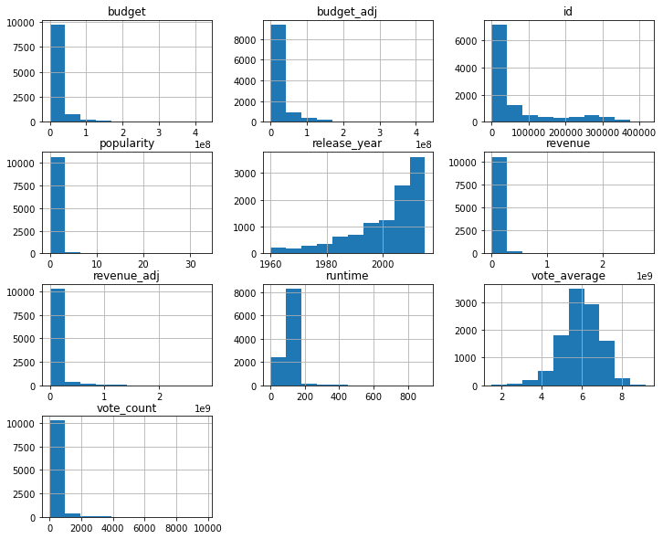

```python
pd.plotting.hist_frame(data[data.dtypes[data.dtypes != 'object'].index], figsize= (12,10));
```

From the above summary statistics and distribution plots, we can notice the following:

- Popularity index is heavily skewed to the right such that 75% of movies or more have a popularity index less than or equal 0.71.
- 50% of movies or more have a budget and revenue values of zeros. Those values are most likely missing rather than zero.
- Minimum runtime is zero which doesn't make sense; it most likely missing. Also, maximum runtime is 900 which is inordinately long; it can be a series, documentary or just data entry mistake. We'll check.

#### Null values

We check which columns have null values?

```python
data.isnull().sum()
```

```
id                         0
imdb_id                   10
popularity                 0
budget                     0
revenue                    0
original_title             0
cast                      76
homepage                7930
director                  44
tagline                 2824
keywords                1493
overview                   4
runtime                    0
genres                    23
production_companies    1030
release_date               0
vote_count                 0
vote_average               0
release_year               0
budget_adj                 0
revenue_adj                0
dtype: int64
```

9 Columns have null values. All columns having null values are of object data type.

#### Duplicated rows

Check if there are any duplicated rows.

```python
print('Number of duplicated rows: ', data.duplicated().sum())
```

```
Number of duplicated rows:  1
```

#### Outlires

From the summary statistics for numeric data above we noticed suspicious extreme values for **runtime** column. Let's first check maximum values.

```python
data[['original_title', 'genres', 'cast','release_year',
      'runtime']].sort_values('runtime', ascending= False).head(10)
```

|  | original_title | genres | cast | release_year | runtime |
| --- | --- | --- | --- | --- | --- |
| 3894 | The Story of Film: An Odyssey | Documentary | Mark Cousins\|Jean-Michel Frodon\|Cari Beauchamp... | 2011 | 900 |
| 4041 | Taken | Science Fiction | Dakota Fanning\|Matt Frewer\|Eric Close\|Emily Be... | 2002 | 877 |
| 2722 | Band of Brothers | Action\|Drama\|War | Damian Lewis\|Ron Livingston\|Frank John Hughes\|... | 2001 | 705 |
| 6176 | Shoah | Documentary | Simon Srebnik\|Michael Podchlebnik\|Motke Zaidl | 1985 | 566 |
| 6181 | North and South, Book I | Drama\|History\|Western | Patrick Swayze\|Philip Casnoff\|Kirstie Alley\|Ge... | 1985 | 561 |
| 6894 | Planet Earth | Documentary | David Attenborough | 2006 | 550 |
| 2214 | The Pacific | War\|Drama\|Action\|Adventure\|History | James Badge Dale\|Joseph Mazzello\|Jon Seda\|Asht... | 2010 | 540 |
| 3356 | John Adams | History\|Drama | Paul Giamatti\|Laura Linney\|Stephen Dillane\|Tom... | 2008 | 501 |
| 1865 | Life | Documentary | David Attenborough\|Oprah Winfrey | 2009 | 500 |
| 3141 | Generation Kill | Drama\|War\|History | Alexander SkarsgÃ¥rd\|James Ransone\|Lee Tergese... | 2008 | 470 |

As expected, movies with longest runtime are documentary and series. So, these values can't be considered as outliers.

### Data Cleaning

We will do the following data cleaning steps:

1. Drop columns id, imbd_id, budget, tagline, runtime, keywords and overview since they are not important for our analysis.
2. Drop homepage column since most of its values are missing.
3. Replace zeros in revenue column by NA.
4. Drop rows with at least 1 missing values.
5. Drop duplicated row.
6. Convert data in cast, genres, director and production_companies columns to list of strings.
7. Convert data type for release_date column from "object" to "datetime".

```python
#Creat a copy of the original dataframe to work with.
data_cleaned = data.copy()
```

#### Step 1&2: Drop unnecessary columns.

```python
data_cleaned.drop(columns= [ 'id', 'budget','imdb_id', 'tagline',
                            'keywords', 'overview', 'runtime','homepage'],inplace= True)
```

#### Step 3: Replace zeros in revenue column.

We will replace the zeros in revenue column by NA since more than 50% of values in this column is missing. So, it would better dealing with these values as missing rather than zeros or any inaccurately imputed values.

```python
#Get index of movies with zero revenue and replace them by nan.
data_cleaned.loc[data_cleaned.revenue == 0, 'revenue'] = np.nan
```

#### Step 4: Drop rows with at least 1 missing value.

```python
data_cleaned.dropna(axis= 0, inplace= True)

#Check if there is any null value exists.
print('Number of null values: ', data_cleaned.isnull().any().sum())
```

```
Number of null values:  0
```

#### Step 5: Drop the duplicated row.

```python
data_cleaned.drop_duplicates(inplace= True)

#Check if there's any duplcated row exists.
print('Number of duplicated rows: ', data_cleaned.duplicated().sum())
```

```
Number of duplicated rows:  0
```

#### Step 6: Convert data into list of strings for columns (cast, genres, production_companies)

```python
columns = ['cast', 'genres', 'director','production_companies']
for col in columns:
    data_cleaned[col] = data_cleaned[col].apply(lambda x: x.split('|'))

#Check columns after conversion
data_cleaned[columns].head()
```

|  | cast | genres | director | production_companies |
| --- | --- | --- | --- | --- |
| 0 | [Chris Pratt, Bryce Dallas Howard, Irrfan Khan... | [Action, Adventure, Science Fiction, Thriller] | [Colin Trevorrow] | [Universal Studios, Amblin Entertainment, Lege... |
| 1 | [Tom Hardy, Charlize Theron, Hugh Keays-Byrne,... | [Action, Adventure, Science Fiction, Thriller] | [George Miller] | [Village Roadshow Pictures, Kennedy Miller Pro... |
| 2 | [Shailene Woodley, Theo James, Kate Winslet, A... | [Adventure, Science Fiction, Thriller] | [Robert Schwentke] | [Summit Entertainment, Mandeville Films, Red W... |
| 3 | [Harrison Ford, Mark Hamill, Carrie Fisher, Ad... | [Action, Adventure, Science Fiction, Fantasy] | [J.J. Abrams] | [Lucasfilm, Truenorth Productions, Bad Robot] |
| 4 | [Vin Diesel, Paul Walker, Jason Statham, Miche... | [Action, Crime, Thriller] | [James Wan] | [Universal Pictures, Original Film, Media Righ... |

#### Step 7: Convert release_date column data type to datetime.

```python
data_cleaned['release_date'] = pd.to_datetime(data_cleaned['release_date'])

#Check data type of release_date column
data_cleaned[['release_date']].dtypes
```

```
release_date    datetime64[ns]
dtype: object
```

## Exploratory Data Analysis

### Q1: Which genres have the highest mean revenue?

To answer this question, we will a new dataframe in which the mean adjusted revenue is calculated for each genre. Then we plot the results on a bar chart.

```python
#Creat a new dataframe for genres, release_year and revenue adjusted.
genre_rev = data_cleaned[['genres', 'release_year', 'revenue_adj']].copy()
genre_rev.head()
```

|  | genres | release_year | revenue_adj |
| --- | --- | --- | --- |
| 0 | [Action, Adventure, Science Fiction, Thriller] | 2015 | 1,392,445,892.52 |
| 1 | [Action, Adventure, Science Fiction, Thriller] | 2015 | 348,161,292.49 |
| 2 | [Adventure, Science Fiction, Thriller] | 2015 | 271,619,025.41 |
| 3 | [Action, Adventure, Science Fiction, Fantasy] | 2015 | 1,902,723,129.80 |
| 4 | [Action, Crime, Thriller] | 2015 | 1,385,748,801.47 |

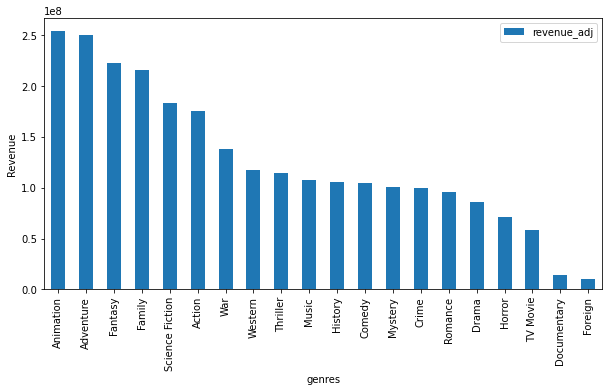

```python
#Unpack lists of genres into separate rows and calculate the mean revenue for each genre.
df = genre_rev.explode('genres').groupby('genres')[['revenue_adj']].mean()\
                                    .sort_values(by= 'revenue_adj', ascending= False)

#Get the index of the top 5 genres in terms of mean revenue.
genre_top5_rev = df[:5].index.tolist()

#Plot genre Vs. Mean Revenue
df.plot(kind= 'bar', figsize= (10, 5))
plt.ylabel('Revenue')
```

We can see that top 5 genres in terms of mean revenue are:

1. Animation.
2. Adventure.
3. Fantasy.
4. Family.
5. Science fiction.

### Q2: How the top 5 genres' revenue changed since 2000?

We build on our answer of the previous question and we will plot the mean revenue for each genre versus the year released.

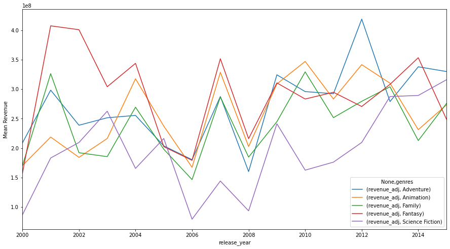

```python
df2 = genre_rev.explode('genres').groupby(['release_year', 'genres']).mean()
df2.loc[(slice(None), genre_top5_rev), :].query('release_year >= 2000')\
                                .unstack().plot(figsize= (15,8), kind = 'line');
plt.ylabel('Mean Revenue');
```

Science fiction and adventure genres have an increasing trend in terms of mean revenue.

### Q3: Which genres are most popular?

Similarly, we will create a new dataframe for the mean popularity for each genre.

```python
#Creat a new dataframe for genres, release_year and revenue adjusted.
genre_pop = data_cleaned[['genres', 'release_year', 'popularity']].copy()
genre_pop.head()
```

|  | genres | release_year | popularity |
| --- | --- | --- | --- |
| 0 | [Action, Adventure, Science Fiction, Thriller] | 2015 | 32.99 |
| 1 | [Action, Adventure, Science Fiction, Thriller] | 2015 | 28.42 |
| 2 | [Adventure, Science Fiction, Thriller] | 2015 | 13.11 |
| 3 | [Action, Adventure, Science Fiction, Fantasy] | 2015 | 11.17 |
| 4 | [Action, Crime, Thriller] | 2015 | 9.34 |

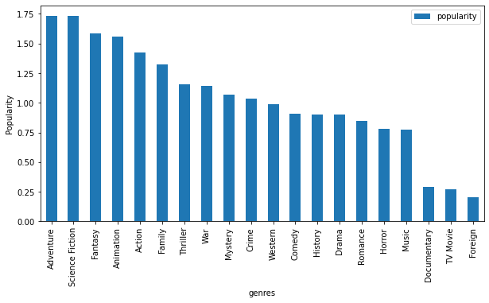

```python
#Unpack lists of genres into separate rows and calculate the mean popularity for each genre
df = genre_pop.explode('genres').groupby('genres')[['popularity']].mean()\
                                    .sort_values(by= 'popularity', ascending= False)
genre_top5_pop = df[:5].index.tolist()

#Plot genre Vs. Mean Popularity
df.plot(kind= 'bar', figsize= (10, 5))
plt.ylabel('Popularity');
```

The bar chart shows that the top 5 popular genres are:

1. Adventure.
2. Science fiction.
3. Fantasy.
4. Animation.
5. Action.

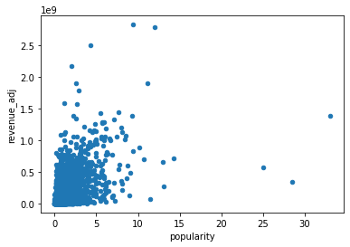

```python
data_cleaned.plot(x= 'popularity', y= 'revenue_adj',kind= 'scatter');
```

The scatter plot above shows that popularity and revenue are positively correlated with some exceptions. There are some movie with very high revenue having relatively low popularity and vice versa.

### Q4: How the top 5 popular genres changed since 2000?

To answer this question we will plot the mean popularity for the 5 top popular genres since 2000.

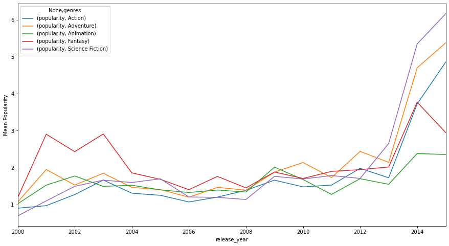

```python
df3 = genre_pop.explode('genres').groupby(['release_year', 'genres']).mean()
df3.loc[(slice(None), genre_top5_pop), :].query('release_year >= 2000')\
                                .unstack().plot(figsize= (15,8), kind = 'line');
plt.ylabel('Mean Popularity');
```

The popularity of Science Fiction, Adventure and Action movies has grown significantly since 2000.

### Q5: Who is the director whose movies got the highest revenues?

We will create a new dataframe with the mean revenue for all movies directed by each director. Then we will plot the results on a bar chart.

```python
direct_rev = data_cleaned[['director', 'revenue_adj']].copy()
direct_rev.head()
```

|  | director | revenue_adj |
| --- | --- | --- |
| 0 | [Colin Trevorrow] | 1,392,445,892.52 |
| 1 | [George Miller] | 348,161,292.49 |
| 2 | [Robert Schwentke] | 271,619,025.41 |
| 3 | [J.J. Abrams] | 1,902,723,129.80 |
| 4 | [James Wan] | 1,385,748,801.47 |

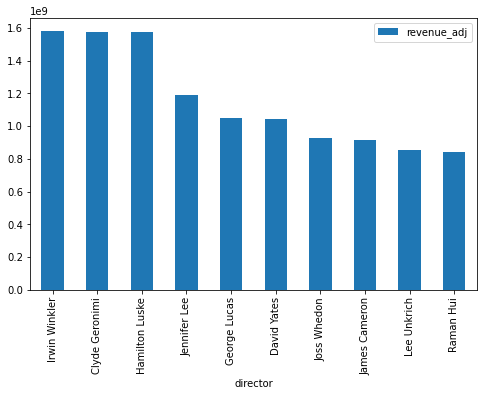

```python
Top10_directors = direct_rev.explode('director').groupby('director').mean().sort_values('revenue_adj',
                                ascending= False)[:10]
Top10_directors.plot(kind='bar', figsize= (8,5));
```

The director of with the highest mean revenues is: Irwin Winkler. Let's check the movie genres directed by **Irwin Winkler**.

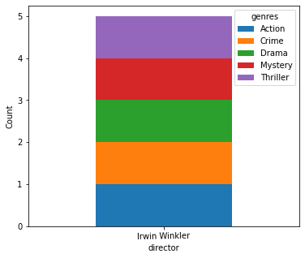

```python
#A stacked bar chart to represent the number of each genre.
data_cleaned[['director', 'genres']].explode('director').explode('genres').\
    query('director == "Irwin Winkler"').groupby('director')['genres'].value_counts().\
    unstack().plot(kind= 'bar', figsize= (6,5) ,stacked= True, rot= True);
plt.ylabel('Count')
```

Movies directed by **Irwin Winkler**:

```python
data_cleaned.explode('director').query('director == "Irwin Winkler"')
```

|  | popularity | revenue | original_title | cast | director | genres | production_companies | release_date | vote_count | vote_average | release_year | budget_adj | revenue_adj |
| --- | --- | --- | --- | --- | --- | --- | --- | --- | --- | --- | --- | --- | --- |
| 8094 | 1.14 | 1,106,279,658.00 | The Net | [Sandra Bullock, Jeremy Northam, Dennis Miller... | Irwin Winkler | [Crime, Drama, Mystery, Thriller, Action] | [Columbia Pictures] | 1995-07-28 | 201 | 5.60 | 1995 | 31,481,271.08 | 1,583,049,536.35 |

Only one movie is directed by **Irwin Winkler** called "The Net" released in 1995. According to the box office, the movie's revenues worldwide is $110.6 million which is the tenth of the revenue in our dataset. But we are not sure if this is a wrong number since the currency is not known for this dataset.

## Conclusions

We can summarize our findings as follows:

- Adventure, fantasy, and science fiction movies are among the most popular and profitable genres.
- There's a positive correlation between popularity and revenue but causality can't be implied.
- There's a grown interest in adventure and science fiction movies since 2000.